# R Notebook

```r
library('DataExplorer')
fim_08.2020 <- read_csv("08-2020/fim-projections-2020-08-04.csv")
fim_08.2020 <- fim_08.2020 %>% select(-X1)
```

In the second estimate, real GDP decreased 31.7 percent in the second quarter, an upward revision of 1.2 percentage points from the previous estimate issued last month. The revision primarily reflected upward revisions to private inventory investment and PCE.

Specifically,

- Q1 Revisions
  - Wages and Salaries
    - BEA revised estimates of first-quarter wages and salaries, personal taxes, and contributions for government social insurance, based on updated data from the BLS Quarterly Census of Employment and Wages program.
    - Wages and salaries are now estimated to have increased $103.6 billion in the first quarter of 2020, a downward revision of $3.4 billion.
- Q2 Revisions
  - Real GDP
    - Decreased 31.7 percent (upward revision of 1.2 percentage points)
    - Reflects upward revisions to private inventory investment and PCE
  - Corporate profits
    - Profits from current production decreased $226.9 billion in Q2 (Q1 decrease was $276.2 billion)
    - Profits of domestic financial corporations increased $39.5 billion (Q1 decrease was $42.2 billion)
    - Profits of domestic nonfinancial corporations decreased $170.1 billion (Q1 decrease was $190.5 billion)
    - Rest-of-the-world profits decreased $96.2 billion (Q1 decrease was $43.5 billion)

## Previous FIM

```r
fim_08.2020 %>% filter(date > "2019-12-31") %>% mutate_if(is.numeric, round, 2)
```

```
unknown timezone 'AET-10AET'unknown timezone 'AET-10AET'
```

| date | fim_bars | fim_bars_ma | state_local_cont | federal_cont | taxes_transfers_cont | subsidies_cont | recession | state_health_outlays | state_social_benefits | state_noncorp_taxes | state_corporate_taxes | state_subsidies | federal_health_outlays | federal_social_benefits | federal_noncorp_taxes | federal_corporate_taxes | federal_subsidies | health_outlays | social_benefits | noncorp_taxes | corporate_taxes | subsidies | federal_nom | federal_cgrants | federal_igrants | pi_federal | state_local_nom | pi_state_local | pi_state_local_c | … |
| --- | --- | --- | --- | --- | --- | --- | --- | --- | --- | --- | --- | --- | --- | --- | --- | --- | --- | --- | --- | --- | --- | --- | --- | --- | --- | --- | --- | --- | --- | --- |
| 2020-03-31 | 0.05 | 0.40 | -0.14 | 0.04 | 0.14 | 0.01 | 1.00 | 179.28 | 186.02 | 1862.40 | 62.70 | 0.60 | 1249.52 | 1574.78 | 3381.60 | 180.50 | 74.50 | 1428.80 | 1760.80 | 5244.10 | 243.20 | 75.10 | 1452.60 | 182.98 | 72.24 | 0.00 | 2381.60 | 0.01 | 0.01 | … |
| 2020-06-30 | 14.62 | 3.90 | -6.75 | 6.89 | 12.88 | 1.60 | 1.33 | 79.90 | 422.84 | 1795.60 | 67.83 | 0.60 | 1419.00 | 3687.16 | 3120.20 | 154.88 | 1087.10 | 1498.90 | 4109.90 | 4915.70 | 271.80 | 1087.70 | 1509.20 | 501.10 | 72.53 | 0.00 | 2330.10 | -0.01 | -0.01 | … |
| 2020-09-30 | 3.50 | 4.67 | 0.47 | -3.67 | 5.00 | 1.70 | NA | 81.88 | 454.66 | 1838.79 | 72.14 | 0.60 | 1441.28 | 2270.17 | 3190.79 | 210.47 | 1328.62 | 1523.16 | 2724.83 | 5029.59 | 282.61 | 1329.22 | 1462.52 | 385.76 | 73.17 | 0.01 | 2248.20 | 0.00 | 0.00 | … |
| 2020-12-31 | 3.83 | 5.50 | 2.10 | -1.28 | 2.84 | 0.17 | NA | 116.94 | 343.15 | 1844.37 | 71.74 | 0.60 | 1410.18 | 2274.11 | 3240.50 | 209.68 | 594.69 | 1527.12 | 2617.26 | 5084.87 | 281.42 | 595.29 | 1474.13 | 321.77 | 73.73 | 0.00 | 2303.20 | 0.00 | 0.00 | … |
| 2021-03-31 | 0.63 | 5.64 | 1.75 | -1.43 | 0.71 | -0.41 | NA | 117.84 | 251.42 | 1849.21 | 75.26 | 0.61 | 1425.44 | 2014.17 | 3294.36 | 220.48 | 180.90 | 1543.29 | 2265.59 | 5143.57 | 295.74 | 181.50 | 1480.29 | 254.74 | 74.02 | 0.00 | 2339.65 | 0.00 | 0.00 | … |
| 2021-06-30 | -6.14 | 0.45 | 1.68 | -1.47 | -5.88 | -0.47 | NA | 164.08 | 192.96 | 1862.31 | 76.80 | 0.61 | 1387.08 | 1958.10 | 3347.23 | 225.56 | 97.07 | 1551.17 | 2151.06 | 5209.55 | 302.36 | 97.67 | 1487.36 | 186.56 | 74.36 | 0.01 | 2378.86 | 0.01 | 0.01 | … |
| 2021-09-30 | -2.17 | -0.96 | 0.19 | -0.12 | -1.95 | -0.28 | NA | 165.53 | 191.51 | 1873.50 | 78.51 | 0.61 | 1404.56 | 1930.67 | 3393.54 | 231.20 | 97.05 | 1570.09 | 2122.18 | 5267.04 | 309.71 | 97.66 | 1495.63 | 186.49 | 74.76 | 0.00 | 2409.16 | 0.01 | 0.01 | … |
| 2021-12-31 | -1.28 | -2.24 | 0.08 | -0.04 | -1.24 | -0.09 | NA | 190.25 | 191.37 | 1889.41 | 79.67 | 0.61 | 1402.57 | 1952.40 | 3450.62 | 239.89 | 97.07 | 1592.82 | 2143.77 | 5340.03 | 319.56 | 97.68 | 1507.57 | 187.75 | 75.33 | 0.00 | 2436.14 | 0.01 | 0.01 | … |

## Updated FIM

```r
fim %>% filter(date > "2019-12-31") %>% mutate_if(is.numeric, round, 2)
```

```
unknown timezone 'AET-10AET'unknown timezone 'AET-10AET'
```

| date | fim_bars | fim_bars_ma | state_local_cont | federal_cont | taxes_transfers_cont | subsidies_cont | recession | state_health_outlays | state_social_benefits | state_noncorp_taxes | state_corporate_taxes | state_subsidies | federal_health_outlays | federal_social_benefits | federal_noncorp_taxes | federal_corporate_taxes | federal_subsidies | health_outlays | social_benefits | noncorp_taxes | corporate_taxes | subsidies | federal_nom | federal_cgrants | federal_igrants | pi_federal | state_local_nom | pi_state_local | pi_state_local_c | … |
| --- | --- | --- | --- | --- | --- | --- | --- | --- | --- | --- | --- | --- | --- | --- | --- | --- | --- | --- | --- | --- | --- | --- | --- | --- | --- | --- | --- | --- | --- | --- |
| 2020-03-31 | 0.06 | 0.40 | -0.14 | 0.04 | 0.16 | 0.01 | 1 | 179.28 | 186.02 | 1862.40 | 62.70 | 0.60 | 1249.52 | 1574.78 | 3376.80 | 180.50 | 74.50 | 1428.80 | 1760.80 | 5239.20 | 243.20 | 75.10 | 1452.60 | 182.98 | 72.24 | 0.00 | 2381.60 | 0.01 | 0.01 | … |
| 2020-06-30 | 14.79 | 3.95 | -6.76 | 6.92 | 14.64 | 1.60 | 1 | 61.09 | 465.22 | 1816.20 | 54.40 | 0.60 | 1420.71 | 3690.18 | 3097.00 | 124.35 | 1086.20 | 1481.80 | 4155.40 | 4913.10 | 227.80 | 1086.80 | 1509.20 | 502.29 | 72.53 | 0.00 | 2333.10 | -0.01 | -0.01 | … |
| 2020-09-30 | 3.60 | 4.74 | 0.46 | -3.66 | 6.79 | 1.69 | NA | 62.89 | 496.31 | 1860.29 | 58.12 | 0.60 | 1443.00 | 2273.23 | 3167.26 | 178.34 | 1327.71 | 1505.89 | 2769.54 | 5027.55 | 236.47 | 1328.32 | 1462.52 | 386.95 | 73.17 | 0.01 | 2251.10 | 0.00 | 0.00 | … |
| 2020-12-31 | 3.92 | 5.59 | 2.09 | -1.28 | 3.11 | 0.17 | NA | 97.74 | 385.55 | 1866.30 | 57.44 | 0.60 | 1411.92 | 2277.22 | 3216.60 | 176.70 | 593.78 | 1509.66 | 2662.77 | 5082.90 | 234.14 | 594.39 | 1474.13 | 322.97 | 73.72 | 0.00 | 2306.17 | 0.00 | 0.00 | … |
| 2021-03-31 | 0.72 | 5.76 | 1.75 | -1.43 | 0.40 | -0.40 | NA | 98.43 | 294.42 | 1871.51 | 60.72 | 0.61 | 1427.21 | 2017.32 | 3270.09 | 186.65 | 179.99 | 1525.64 | 2311.74 | 5141.60 | 247.37 | 180.59 | 1480.29 | 255.94 | 74.02 | 0.00 | 2342.66 | 0.00 | 0.00 | … |
| 2021-06-30 | -6.06 | 0.54 | 1.67 | -1.47 | -6.27 | -0.47 | NA | 144.46 | 236.57 | 1884.96 | 62.03 | 0.61 | 1388.87 | 1961.30 | 3322.60 | 190.88 | 96.15 | 1533.32 | 2197.87 | 5207.56 | 252.90 | 96.76 | 1487.36 | 187.74 | 74.36 | 0.01 | 2381.92 | 0.01 | 0.01 | … |
| 2021-09-30 | -2.10 | -0.88 | 0.19 | -0.12 | -2.17 | -0.28 | NA | 145.69 | 235.64 | 1896.53 | 63.49 | 0.61 | 1406.36 | 1933.90 | 3368.54 | 195.66 | 96.13 | 1552.05 | 2169.54 | 5265.07 | 259.15 | 96.75 | 1495.63 | 187.67 | 74.76 | 0.00 | 2412.26 | 0.01 | 0.01 | … |
| 2021-12-31 | -1.23 | -2.17 | 0.08 | -0.04 | -1.27 | -0.09 | NA | 170.17 | 236.00 | 1912.69 | 64.49 | 0.61 | 1404.39 | 1955.67 | 3425.32 | 203.11 | 96.15 | 1574.56 | 2191.67 | 5338.01 | 267.60 | 96.76 | 1507.57 | 188.93 | 75.33 | 0.00 | 2439.27 | 0.01 | 0.01 | … |

## Difference in projections

```r
fim_diff <- fim - fim_08.2020
fim_diff <- fim_diff %>% mutate(date = fim$date)
fim_diff <- fim_diff %>% filter(date > "2019-12-31")
```

```
unknown timezone 'AET-10AET'unknown timezone 'AET-10AET'
```

```r
fim_diff %>% mutate_if(is.numeric, round, 2)
```

| date | fim_bars | fim_bars_ma | state_local_cont | federal_cont | taxes_transfers_cont | subsidies_cont | recession | state_health_outlays | state_social_benefits | state_noncorp_taxes | state_corporate_taxes | state_subsidies | federal_health_outlays | federal_social_benefits | federal_noncorp_taxes | federal_corporate_taxes | federal_subsidies | health_outlays | social_benefits | noncorp_taxes | corporate_taxes | subsidies | federal_nom | federal_cgrants | federal_igrants | pi_federal | state_local_nom | pi_state_local | pi_state_local_c | … |
| --- | --- | --- | --- | --- | --- | --- | --- | --- | --- | --- | --- | --- | --- | --- | --- | --- | --- | --- | --- | --- | --- | --- | --- | --- | --- | --- | --- | --- | --- | --- |
| 2020-03-31 | 0.01 | 0.00 | 0.00 | 0.00 | 0.02 | 0.00 | 0.00 | 0.00 | 0.00 | 0.00 | 0.00 | 0 | 0.00 | 0.00 | -4.80 | 0.00 | 0.00 | 0.00 | 0.00 | -4.90 | 0.00 | 0.00 | 0 | 0.00 | 0 | 0 | 0.00 | 0 | 0 | … |
| 2020-06-30 | 0.18 | 0.05 | -0.01 | 0.03 | 1.76 | 0.00 | -0.33 | -18.81 | 42.38 | 20.60 | -13.43 | 0 | 1.71 | 3.02 | -23.20 | -30.53 | -0.90 | -17.10 | 45.50 | -2.60 | -44.00 | -0.90 | 0 | 1.19 | 0 | 0 | 3.00 | 0 | 0 | … |
| 2020-09-30 | 0.10 | 0.07 | 0.00 | 0.01 | 1.79 | -0.01 | NA | -18.99 | 41.65 | 21.50 | -14.02 | 0 | 1.73 | 3.06 | -23.53 | -32.12 | -0.90 | -17.26 | 44.71 | -2.04 | -46.14 | -0.90 | 0 | 1.20 | 0 | 0 | 2.89 | 0 | 0 | … |
| 2020-12-31 | 0.09 | 0.09 | -0.01 | 0.01 | 0.26 | 0.00 | NA | -19.20 | 42.41 | 21.93 | -14.30 | 0 | 1.75 | 3.10 | -23.90 | -32.98 | -0.91 | -17.46 | 45.51 | -1.97 | -47.28 | -0.91 | 0 | 1.20 | 0 | 0 | 2.96 | 0 | 0 | … |
| 2021-03-31 | 0.09 | 0.11 | -0.01 | 0.01 | -0.31 | 0.00 | NA | -19.41 | 42.99 | 22.29 | -14.54 | 0 | 1.76 | 3.16 | -24.27 | -33.83 | -0.91 | -17.65 | 46.15 | -1.97 | -48.37 | -0.91 | 0 | 1.19 | 0 | 0 | 3.01 | 0 | 0 | … |
| 2021-06-30 | 0.08 | 0.09 | -0.01 | 0.01 | -0.39 | 0.00 | NA | -19.63 | 43.61 | 22.65 | -14.77 | 0 | 1.78 | 3.19 | -24.64 | -34.68 | -0.91 | -17.84 | 46.81 | -1.99 | -49.45 | -0.91 | 0 | 1.19 | 0 | 0 | 3.06 | 0 | 0 | … |
| 2021-09-30 | 0.06 | 0.08 | 0.00 | 0.00 | -0.22 | 0.00 | NA | -19.84 | 44.13 | 23.03 | -15.02 | 0 | 1.80 | 3.23 | -25.00 | -35.54 | -0.92 | -18.03 | 47.36 | -1.98 | -50.55 | -0.92 | 0 | 1.19 | 0 | 0 | 3.10 | 0 | 0 | … |
| 2021-12-31 | 0.06 | 0.07 | 0.00 | 0.00 | -0.03 | 0.00 | NA | -20.08 | 44.63 | 23.28 | -15.18 | 0 | 1.83 | 3.28 | -25.30 | -36.78 | -0.92 | -18.26 | 47.91 | -2.02 | -51.96 | -0.92 | 0 | 1.19 | 0 | 0 | 3.13 | 0 | 0 | … |

```r
fim_diff_percent <- (fim - fim_08.2020)

fim_diff_percent <- (fim_diff_percent/fim_08.2020)*100
```

```
Incompatible methods ("/.difftime", "Ops.Date") for "/"
```

```r
fim_diff_percent <- fim_diff_percent %>% mutate(date = fim$date) %>% filter(date > "2019-12-31")
```

```
unknown timezone 'AET-10AET'unknown timezone 'AET-10AET'
```

```r
fim_diff_percent %>% mutate_if(is.numeric, round, 2)
```

| date | fim_bars | fim_bars_ma | state_local_cont | federal_cont | taxes_transfers_cont | subsidies_cont | recession | state_health_outlays | state_social_benefits | state_noncorp_taxes | state_corporate_taxes | state_subsidies | federal_health_outlays | federal_social_benefits | federal_noncorp_taxes | federal_corporate_taxes | federal_subsidies | health_outlays | social_benefits | noncorp_taxes | corporate_taxes | subsidies | federal_nom | federal_cgrants | federal_igrants | pi_federal | state_local_nom | pi_state_local | pi_state_local_c | … |
| --- | --- | --- | --- | --- | --- | --- | --- | --- | --- | --- | --- | --- | --- | --- | --- | --- | --- | --- | --- | --- | --- | --- | --- | --- | --- | --- | --- | --- | --- | --- |
| 2020-03-31 | 20.74 | 0.68 | 0.00 | 0.00 | 11.47 | 0.00 | 0 | 0.00 | 0.00 | 0.00 | 0.00 | 0 | 0.00 | 0.00 | -0.14 | 0.00 | 0.00 | 0.00 | 0.00 | -0.09 | 0.00 | 0.00 | 0 | 0.00 | 0 | 0.00 | 0.00 | 0.0 | 0.00 | … |
| 2020-06-30 | 1.20 | 1.20 | 0.13 | 0.42 | 13.65 | -0.09 | -25 | -23.54 | 10.02 | 1.15 | -19.80 | 0 | 0.12 | 0.08 | -0.74 | -19.71 | -0.08 | -1.14 | 1.11 | -0.05 | -16.19 | -0.08 | 0 | 0.24 | 0 | 25.91 | 0.13 | -14.6 | -13.47 | … |
| 2020-09-30 | 2.88 | 1.54 | -0.95 | -0.40 | 35.73 | -0.47 | NA | -23.19 | 9.16 | 1.17 | -19.43 | 0 | 0.12 | 0.13 | -0.74 | -15.26 | -0.07 | -1.13 | 1.64 | -0.04 | -16.33 | -0.07 | 0 | 0.31 | 0 | 0.00 | 0.13 | 0.0 | 0.00 | … |
| 2020-12-31 | 2.28 | 1.70 | -0.35 | -0.39 | 9.20 | -0.99 | NA | -16.42 | 12.36 | 1.19 | -19.93 | 0 | 0.12 | 0.14 | -0.74 | -15.73 | -0.15 | -1.14 | 1.74 | -0.04 | -16.80 | -0.15 | 0 | 0.37 | 0 | 0.00 | 0.13 | 0.0 | 0.00 | … |
| 2021-03-31 | 14.94 | 2.03 | -0.35 | -0.38 | -43.82 | -0.20 | NA | -16.47 | 17.10 | 1.21 | -19.32 | 0 | 0.12 | 0.16 | -0.74 | -15.34 | -0.50 | -1.14 | 2.04 | -0.04 | -16.36 | -0.50 | 0 | 0.47 | 0 | 0.00 | 0.13 | 0.0 | 0.00 | … |
| 2021-06-30 | -1.26 | 19.78 | -0.35 | -0.38 | 6.71 | -0.26 | NA | -11.96 | 22.60 | 1.22 | -19.23 | 0 | 0.13 | 0.16 | -0.74 | -15.38 | -0.94 | -1.15 | 2.18 | -0.04 | -16.36 | -0.93 | 0 | 0.64 | 0 | 0.00 | 0.13 | 0.0 | 0.00 | … |
| 2021-09-30 | -2.95 | -8.38 | -0.15 | -0.18 | 11.08 | -0.17 | NA | -11.98 | 23.05 | 1.23 | -19.13 | 0 | 0.13 | 0.17 | -0.74 | -15.37 | -0.94 | -1.15 | 2.23 | -0.04 | -16.32 | -0.94 | 0 | 0.64 | 0 | 0.00 | 0.13 | 0.0 | 0.00 | … |
| 2021-12-31 | -4.60 | -3.28 | -0.10 | 0.15 | 2.75 | 0.27 | NA | -10.56 | 23.32 | 1.23 | -19.06 | 0 | 0.13 | 0.17 | -0.73 | -15.33 | -0.95 | -1.15 | 2.23 | -0.04 | -16.26 | -0.94 | 0 | 0.63 | 0 | 0.00 | 0.13 | 0.0 | 0.00 | … |

```r
fim_new <- fim %>% mutate(id = "Updated") %>% filter(date > "2019-12-31") %>% mutate_if(is.numeric, round, 2)
```

```
unknown timezone 'AET-10AET'unknown timezone 'AET-10AET'
```

```r
fim_old <- fim_08.2020 %>% mutate(id = "Previous") %>% filter(date > "2019-12-31") %>% mutate_if(is.numeric, round, 2)
```

```
unknown timezone 'AET-10AET'unknown timezone 'AET-10AET'
```

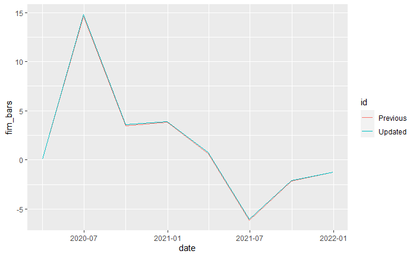

```r
fim_both <- rbind(fim_old, fim_new) %>% group_by(id, date)

ggplot(fim_both, aes(x = date, y = fim_bars, group = id, color = id)) + geom_line()
```

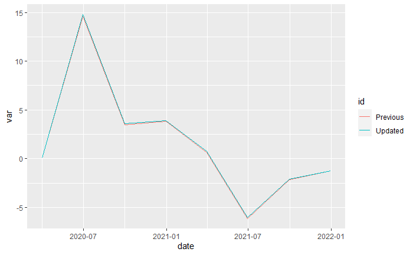

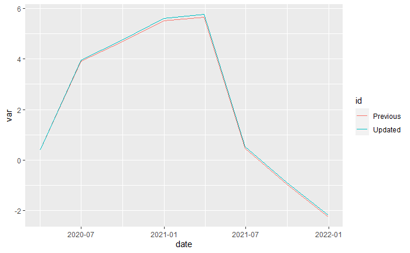

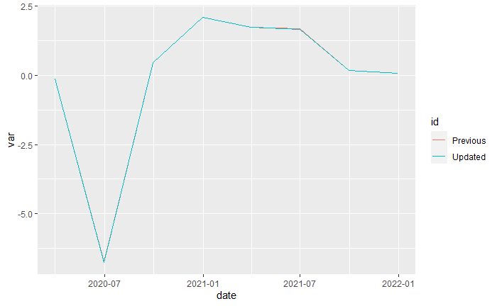

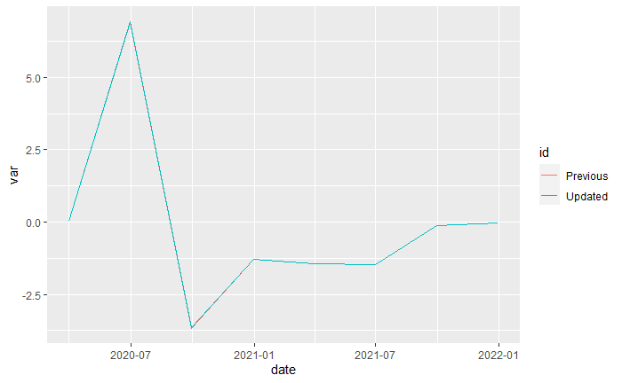

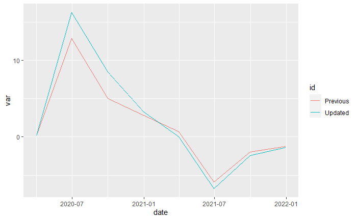

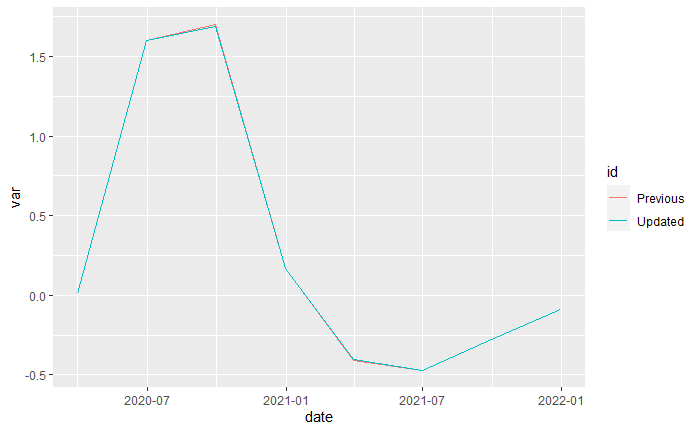

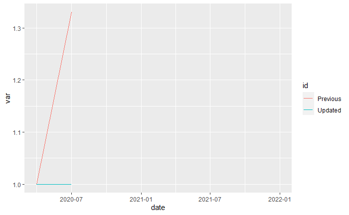

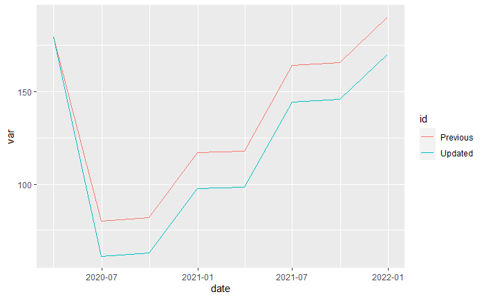

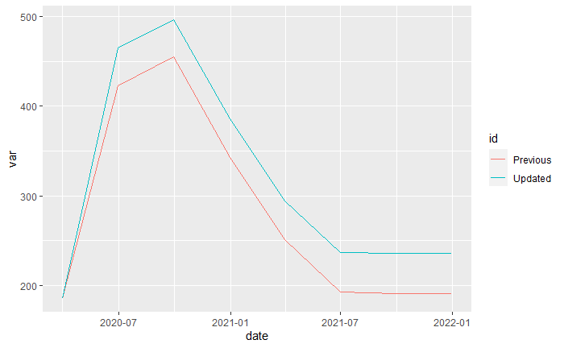

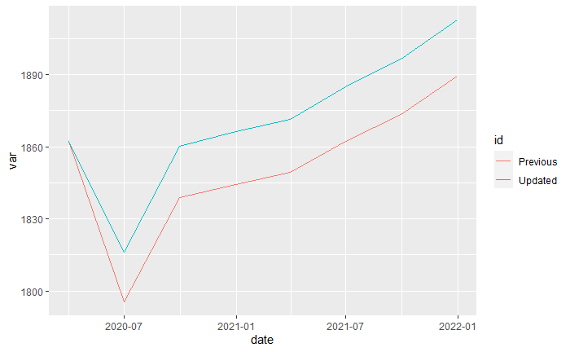

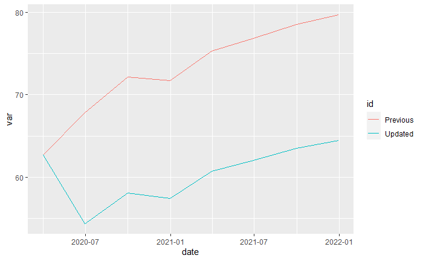

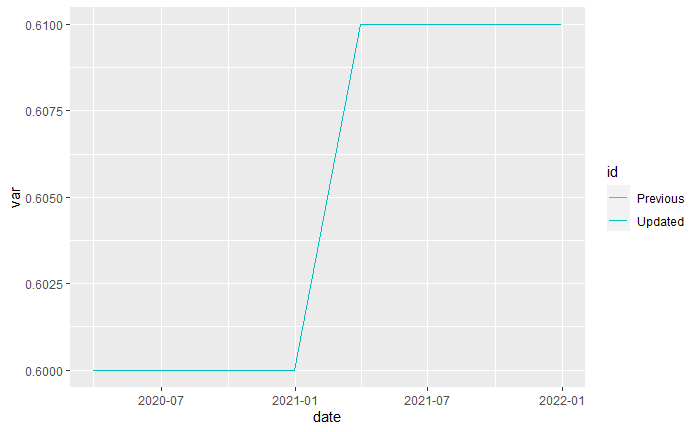

[78 more figures not shown]

```r
lapply(fim_both[,2:length(fim_both)], compare)
```

```
unknown timezone 'AET-10AET'unknown timezone 'AET-10AET'
```

## Updated FIM

[figure not shown]

```r
# construct figures

fimbars1_old = bp(data = fim_08.2020[,c("date","fim_bars")],
              labelz = c(" Quarterly fiscal impact"),
              start.date = "2000-01-01",
              end.date = last_proj_date,
              t = "Hutchins Center Fiscal Impact Measure: Total",
              sub = "Fiscal Policy Contribution to Real GDP Growth, percentage points",
              colorz = total_pink,
              cap = "Source: Hutchins Center calculations from Bureau of Economic Analysis and Congressional Budget Office data; \ngrey shaded areas indicate recessions and yellow shaded areas indicate projection.") +
  geom_line(data = fim, aes(x = date, y = fim_bars_ma, colour = "4-quarter moving-average")) +
  geom_point(data = fim, aes(x = date, y = fim_bars_ma, colour = "4-quarter moving-average"), size = 1) +
  scale_color_manual(" ", values=c("4-quarter moving-average" ="black", "4-quarter moving-average" ="black")) +
  geom_text(aes(x=Sys.Date()+350, y = max_y), label = "Projection", cex = 2) +
  projection_shade +
  recession_shade +
  ylim(min_y, max_y) +
  guidez
```

[output not shown]

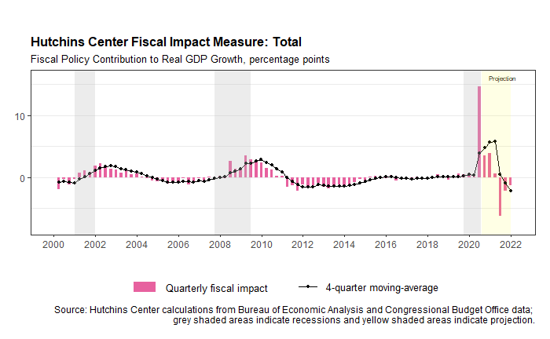

```r
fimbars1_old
```

```r
NA
NA
```